# Poisson Depth Recovery

In the previous work, we introduced the Poisson image editing for seamless editing of images regions. We are now ready to put this knowledge into Poisson depth recovery.

## Accessing and Reading Data Sets

Note that the depth map and normal map are both generated from mathematical expression, so they can be regarded as ground truth.

Later we will choose some pixels in depth map and the whole normal map to construct the Poisson equation.

```python
mask = np.load("data/mask.npy")
depth = np.load("data/depth.npy")
gt_depth = depth.copy()
normal = np.load("data/normal.npy")
```

## Visualization of the Ground Truth

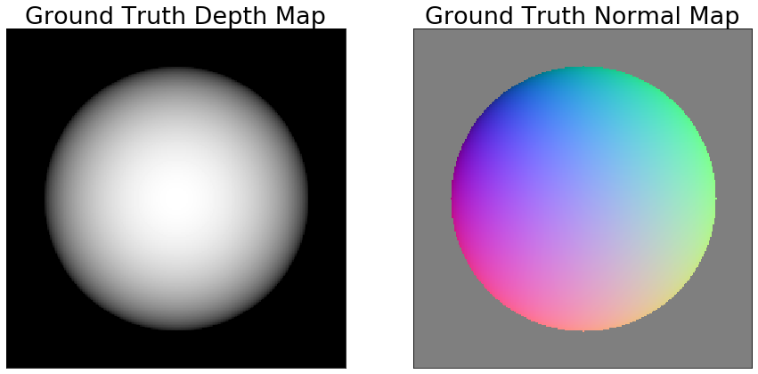

```python
plt.show()
```

## Visualization of the Known Depth Map

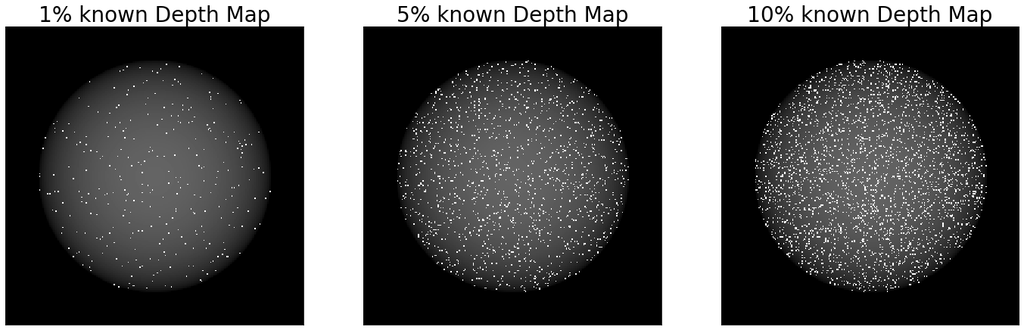

```python
plt.show()
```

## Solve Poisson Equation

Apply the weight $w$ to depth map to decide how much we trust our depth map.

```python
npy_f_lst = ["data/random_001.npy","data/random_005.npy","data/random_010.npy"]
output_depth = []
for npy_f in npy_f_lst:
    equation_num = 0
    t = np.where(mask==1)
    n = len(t[0])
    k = np.load(npy_f)
    tt = np.array([t[0],t[1]]).T #tt is the known depth pixel's coordinate [[28,128], [29,114]...]
    A_row = []
    A_col = []
    A_data = []
    b = []
    w = 0.1 # the weight for how much we trust the depth map
    d = {} # mapping coordinates with linear indices
    for i in range(n):
        d[(tt[i][0],tt[i][1])] = i
    for i in range(n):
        x = tt[i][0]
        y = tt[i][1]
        if i in k: # if the i-th pixel's depth is known
            A_row.append(equation_num)
            A_col.append(i)
            A_data.append(w)
            b.append(w*depth[x][y])
            equation_num += 1
        else:
            if (x, y-1) in d and (x, y+1) in d and (x-1, y) in d and (x+1, y) in d:
#                 if not(i in k and i-1 in k and i+1 in k and d[(x-1, y)] in k and d[(x+1, y)] in k):
                A_row.append(equation_num)
                A_col.append(i)
                A_data.append(4)
                b.append((normal[x+1][y][1]-normal[x-1][y][1]+normal[x][y+1][0]-normal[x][y-1][0])/2)
                if i-1 in k:
                    b[-1] += depth[x][y-1]
                else:
                    A_row.append(equation_num)
                    A_col.append(i-1)
                    A_data.append(-1)
                if i+1 in k:
                    b[-1] += depth[x][y+1]
                else:
                    A_row.append(equation_num)
                    A_col.append(i+1)
                    A_data.append(-1)

                if d[(x-1, y)] in k:
                    b[-1] += depth[x-1][y]
                else:
                    A_row.append(equation_num)
                    A_col.append(d[(x-1, y)])
                    A_data.append(-1)
                if d[(x+1, y)] in k:
                    b[-1] += depth[x+1][y]
                else:
                    A_row.append(equation_num)
                    A_col.append(d[(x+1, y)])
                    A_data.append(-1)
                equation_num += 1

    A_row = np.array(A_row)
    A_col = np.array(A_col)
    A_data = np.array(A_data)
    b = np.array(b)
    A = sparse.csr_matrix((A_data, (A_row, A_col)), shape=(equation_num, n))
    res = lsmr(A, b)[0]
    for i in range(n):
        x = tt[i][0]
        y = tt[i][1]
        if (x-1, y) in d and (x+1, y) in d and (x, y-1) in d and (x, y+1) in d:
#             if not(i in k and i-1 in k and i+1 in k and d[(x-1, y)] in k and d[(x+1, y)] in k):
            depth[x][y] = res[i]
    output_depth.append(depth)
    depth = gt_depth.copy()
```

## Visualization of the Result

When 1% of depth map is known.

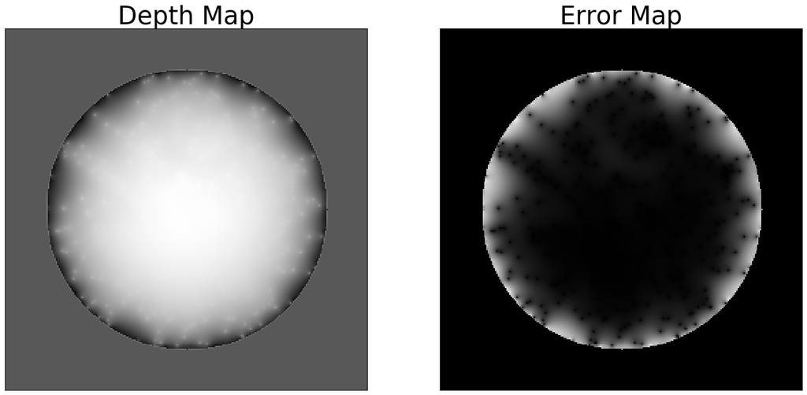

```python
plt_figure(output_depth[0], abs(output_depth[0]-gt_depth))
```

When 5% of depth map is known.

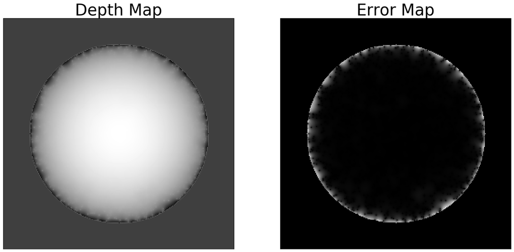

```python
plt_figure(output_depth[1], abs(output_depth[1]-gt_depth))
```

When 10% of depth map is known.

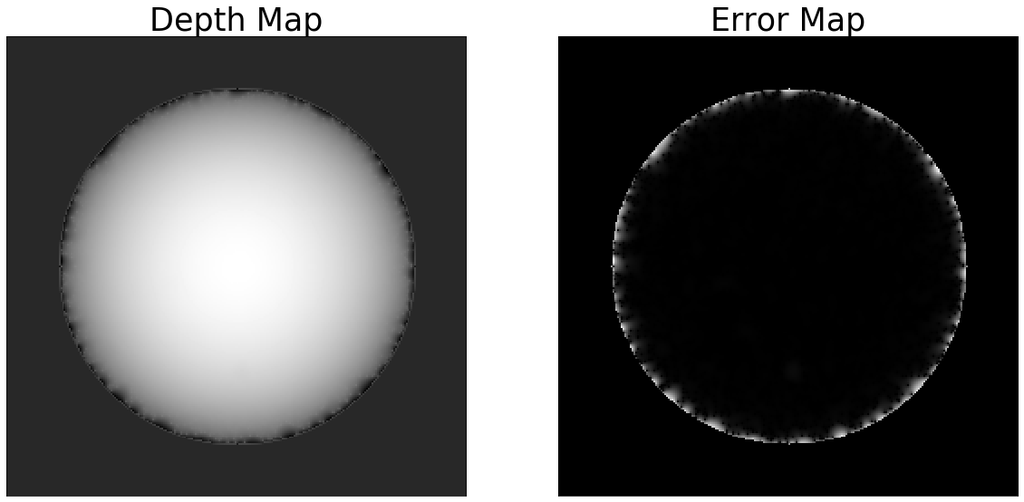

```python
plt_figure(output_depth[2], abs(output_depth[2]-gt_depth))
```

### When $w=2$

When 1% of depth map is known.

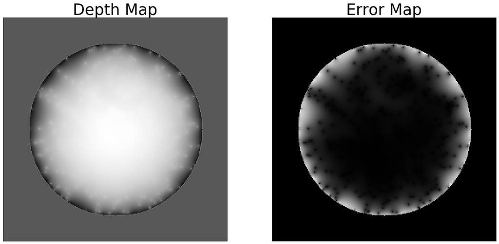

```python
plt_figure(output_depth[0], abs(output_depth[0]-gt_depth))
```

When 5% of depth map is known.

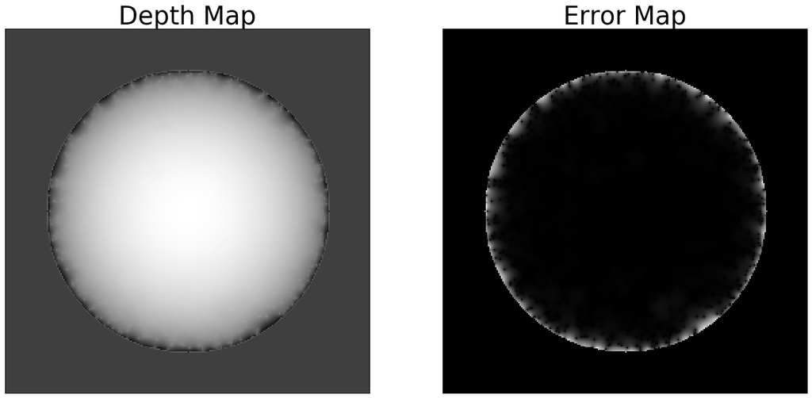

```python
plt_figure(output_depth[1], abs(output_depth[1]-gt_depth))
```

When 10% of depth map is known.

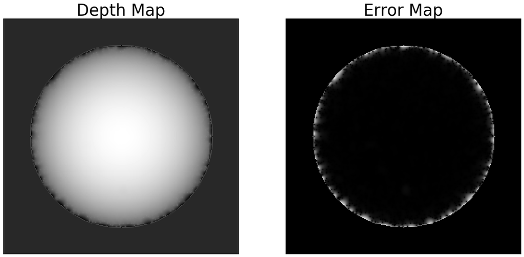

```python
plt_figure(output_depth[2], abs(output_depth[2]-gt_depth))
```

### When $w=10$

When 1% of depth map is known.

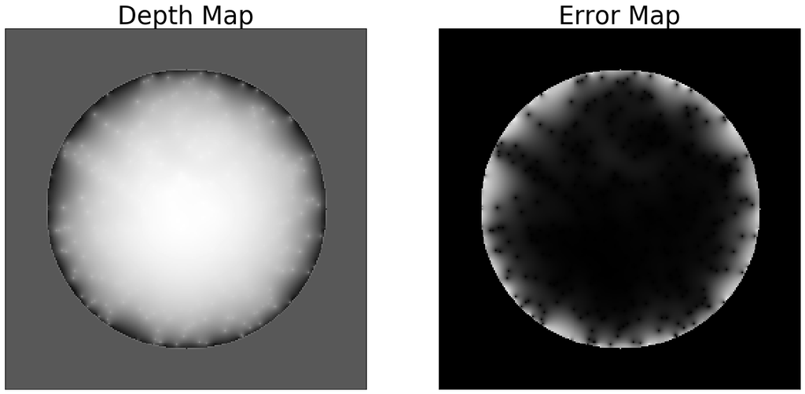

```python
plt_figure(output_depth[0], abs(output_depth[0]-gt_depth))
```

When 5% of depth map is known.

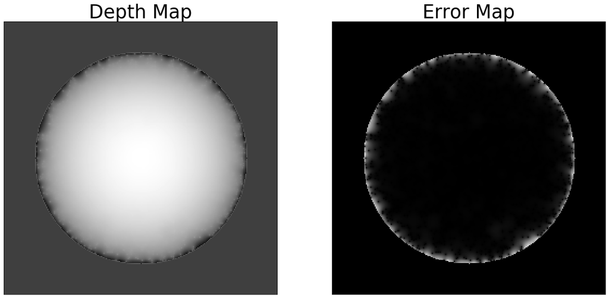

```python
plt_figure(output_depth[1], abs(output_depth[1]-gt_depth))
```

When 10% of depth map is known.

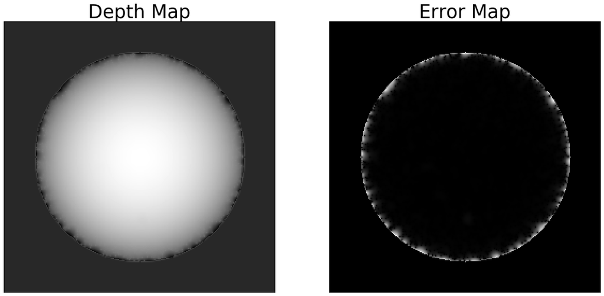

```python
plt_figure(output_depth[2], abs(output_depth[2]-gt_depth))
```

### When $w=0.5$

When 1% of depth map is known.

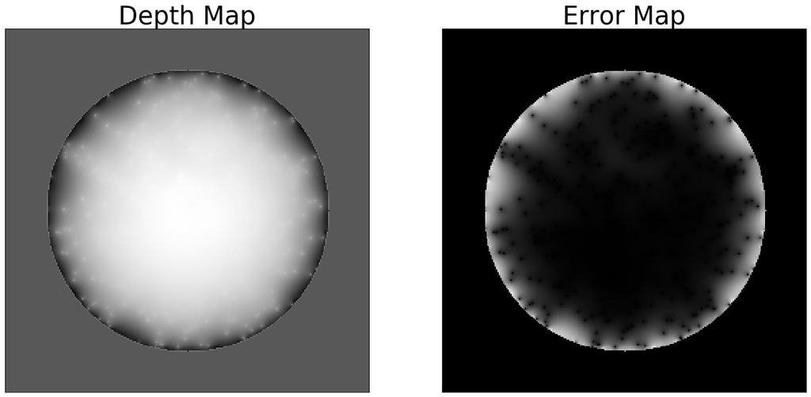

```python
plt_figure(output_depth[0], abs(output_depth[0]-gt_depth))
```

When 5% of depth map is known.

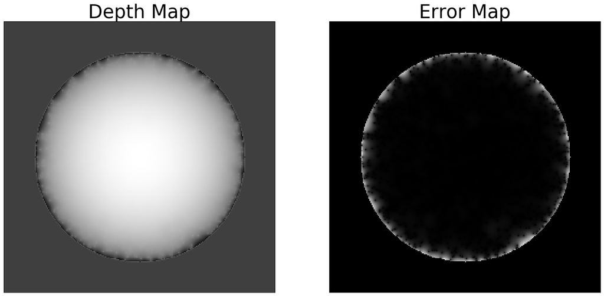

```python
plt_figure(output_depth[1], abs(output_depth[1]-gt_depth))
```

When 10% of depth map is known.

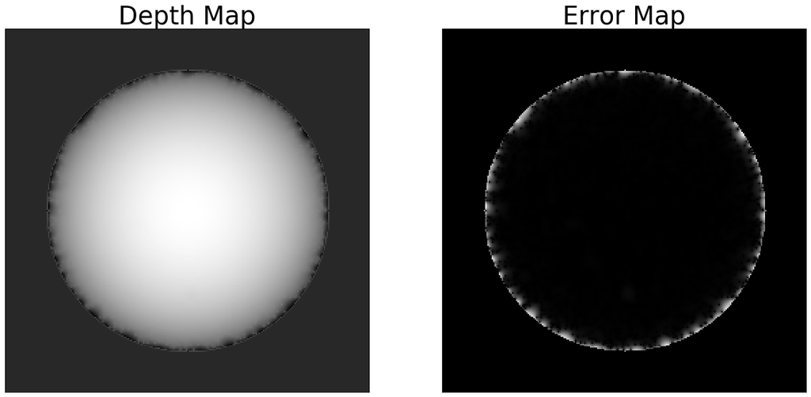

```python
plt_figure(output_depth[2], abs(output_depth[2]-gt_depth))
```

### When $w=0.1$

When 1% of depth map is known.

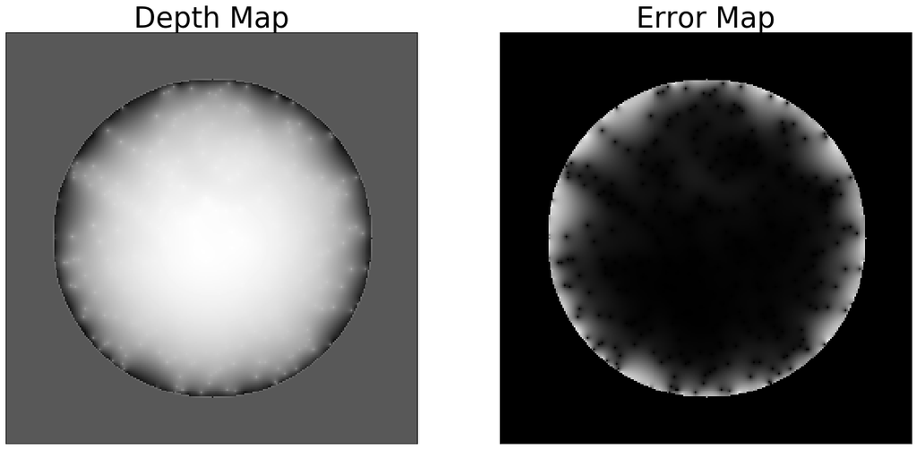

```python
plt_figure(output_depth[0], abs(output_depth[0]-gt_depth))
```

When 5% of depth map is known.

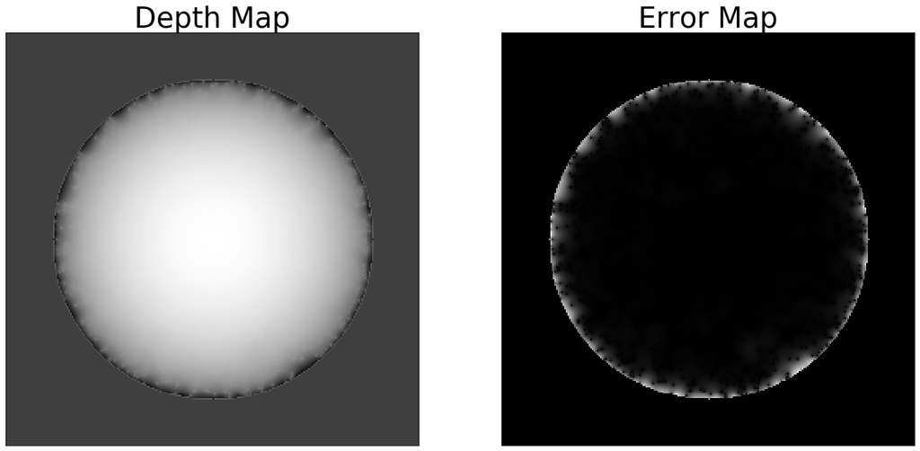

```python
plt_figure(output_depth[1], abs(output_depth[1]-gt_depth))
```

When 10% of depth map is known.

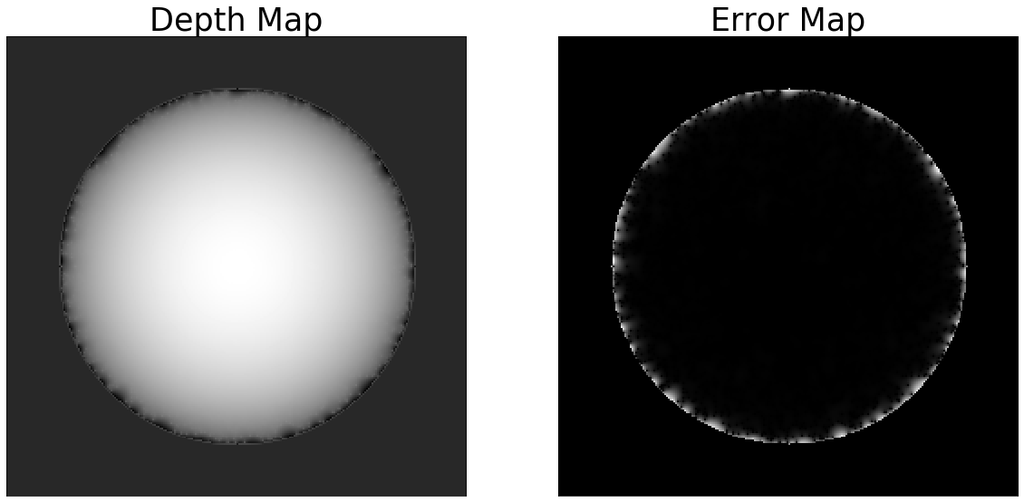

```python
plt_figure(output_depth[2], abs(output_depth[2]-gt_depth))
```

## Compare Depth Error

$w = 2$

[figure not shown]

$w = 10$

[figure not shown]

$w = 0.1$

[figure not shown]

$w = 0.5$

[figure not shown]

## Seperately Use X and Y Component(Non-Poisson Way)

We can also seperately use the x-component and y-component of the normal vector.The matrix will be nearly twice taller than Poisson method.

```python
npy_f_lst = ["data/random_001.npy","data/random_005.npy","data/random_010.npy"]
output_depth = []
for npy_f in npy_f_lst:
    equation_num = 0
    t = np.where(mask==1)
    n = len(t[0])
    k = np.load(npy_f)
    tt = np.array([t[0],t[1]]).T #tt is the known depth pixel's coordinate [[28,128], [29,114]...]
    A_row = []
    A_col = []
    A_data = []
    b = []
    w = 1
    d = {} # mapping coordinates with linear indices
    for i in range(n):
        d[(tt[i][0],tt[i][1])] = i
    for i in range(n):
        x = tt[i][0]
        y = tt[i][1]
        if i in k: # if the i-th pixel's depth is known
            A_row.append(equation_num)
            A_col.append(i)
            A_data.append(w)
            b.append(w*depth[x][y])
            equation_num += 1
        else:
            if (x, y-1) in d and (x, y+1) in d:
                if not(i-1 in k and i+1 in k):
                    b.append(2*normal[x][y][0])
                    if i-1 in k:
                        b[-1] += depth[x][y-1]
                    else:
                        A_row.append(equation_num)
                        A_col.append(i-1)
                        A_data.append(-1)
                    if i+1 in k:
                        b[-1] -= depth[x][y+1]
                    else:
                        A_row.append(equation_num)
                        A_col.append(i+1)
                        A_data.append(1)
                    equation_num += 1

            if (x-1, y) in d and (x+1, y) in d:
                if not(d[(x-1, y)] in k and d[(x+1,y)] in k):
                    b.append(2*normal[x][y][1])
                    if d[(x-1, y)] in k:
                        b[-1] += depth[x-1][y]
                    else:
                        A_row.append(equation_num)
                        A_col.append(d[(x-1, y)])
                        A_data.append(-1)
                    if d[(x+1,y)] in k:
                        b[-1] -= depth[x+1][y]
                    else:
                        A_row.append(equation_num)
                        A_col.append(d[(x+1, y)])
                        A_data.append(1)
                    equation_num += 1
    A_row = np.array(A_row)
    A_col = np.array(A_col)
    A_data = np.array(A_data)
    b = np.array(b)
    A = sparse.csr_matrix((A_data, (A_row, A_col)), shape=(equation_num, n))
    res = lsmr(A, b)[0]
    for i in range(n):
        x = tt[i][0]
        y = tt[i][1]
#         if i in k: # if the i-th pixel's depth is known
#             pass
#         else:
        if (x-1, y) in d and (x+1, y) in d and (x, y-1) in d and (x, y+1) in d:
            depth[x][y] = res[i]
    output_depth.append(depth)
    depth = gt_depth.copy()
```

## Visualization of the Result

When 1% of depth map is known.

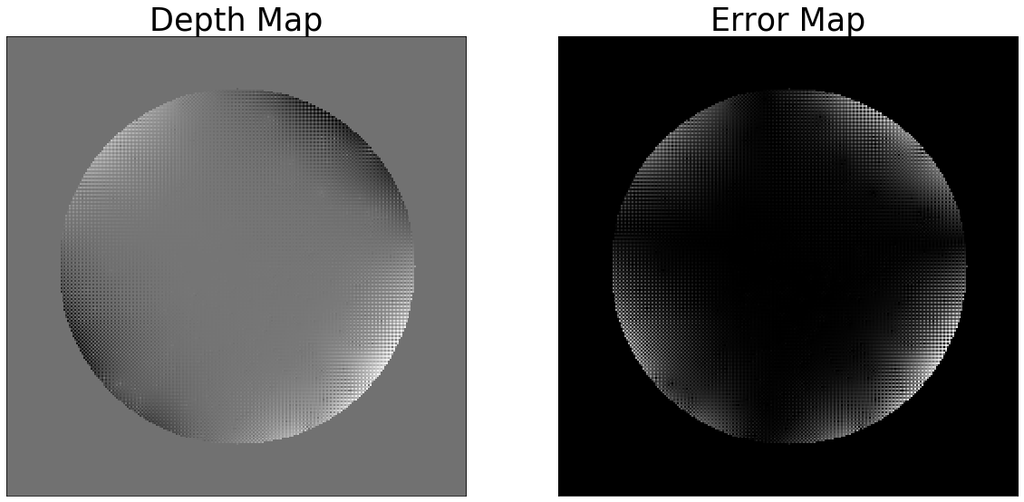

```python
plt_figure(output_depth[0], abs(output_depth[0]-gt_depth))
```

When 5% of depth map is known.

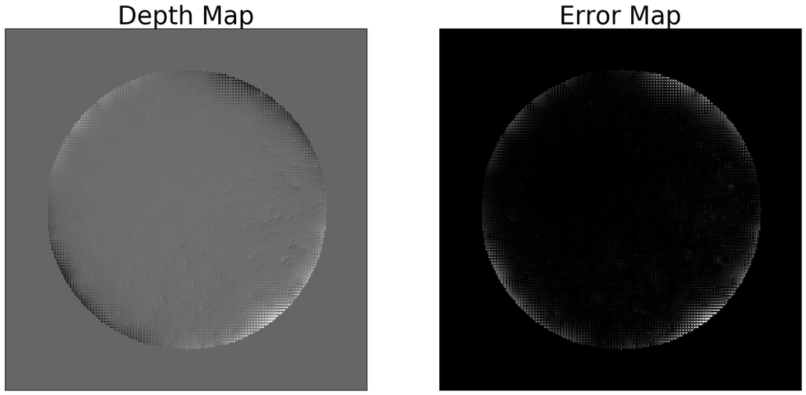

```python
plt_figure(output_depth[1], abs(output_depth[1]-gt_depth))
```

When 10% of depth map is known.

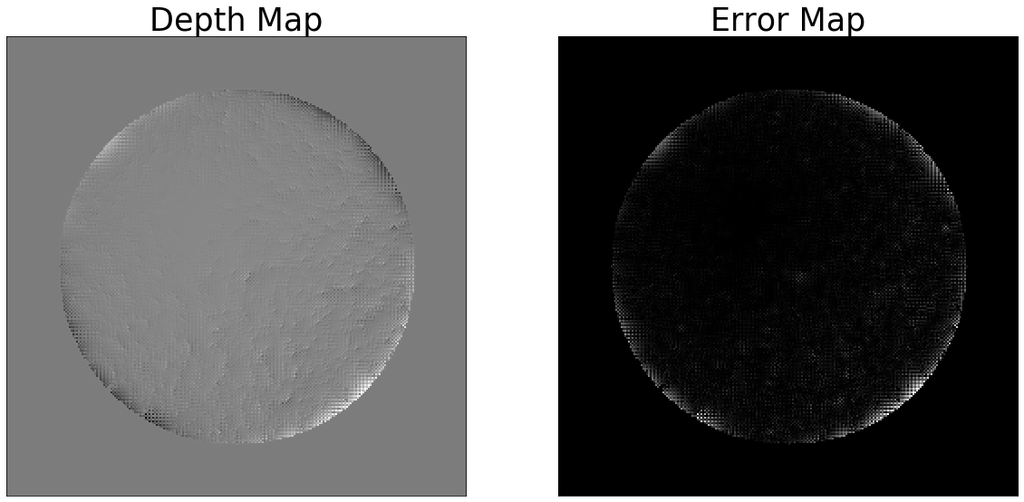

```python
plt_figure(output_depth[2], abs(output_depth[2]-gt_depth))
```